Healthcare Data Science · Clinical Risk Prediction

# Predicting Patient Outcomes After Mitral Valve Surgery

A data-driven investigation into whether patient characteristics can predict which patients are more likely to show clinical improvement following surgery — and what this means for risk stratification and future research.

Dataset 1,000 Surgical Patients

Outcome Post-Surgery Improvement (Yes/No)

Models Tested 6 Machine Learning Models

Written for Clinical & Non-Technical Audiences

Section 01

## Plain-English Summary

*Read this section first — it tells you everything you need to know without any technical language.*

**⚠ Honest Finding:** After testing six different computer models on this dataset, we found that the available patient information — surgery type, gender, smoking status, and whether the valve was already showing improvement at baseline — is **not sufficient to predict who will improve after surgery**. This is an important finding in itself.

### The Question We Asked

After a patient undergoes mitral valve surgery, will their heart valve function improve? This matters enormously in healthcare: if we could predict in advance which patients are likely to improve — and which are at higher risk of a poor outcome — doctors could adjust treatment plans, monitor patients more closely, and use resources more efficiently.

### What We Did

We used data from 1,000 patients who had mitral valve surgery. For each patient, we knew their surgery type (minimally invasive "Mini" or standard "Conventional"), their gender, whether they smoked, and whether their valve was already showing some improvement before the operation. We built six different computer models and asked each one to predict whether a patient would improve at their 12-month follow-up.

### What We Found

46.9%

Patients who improved post-surgery

~0.50

Best model AUC score (0.5 = random guessing)

6

Machine learning models tested

Every model we tested performed at roughly the same level as **random guessing**. This tells us something important: *the variables we have are not the right ones to predict this outcome*. This is not a technical failure — it is a genuine scientific insight that should guide what data is collected in future studies.

Section 02

## The Clinical Problem — Why This Matters

### What is Mitral Valve Disease?

The mitral valve is one of four valves in the heart. It sits between the left atrium and the left ventricle and controls blood flow. When it stops working properly — either because it leaks (regurgitation) or because it becomes too stiff to open fully (stenosis) — the heart has to work harder, which can lead to breathlessness, fatigue, and in severe cases, heart failure.

Surgery to repair or replace the mitral valve is an established treatment. However, patients respond differently: some experience significant improvement in heart function and quality of life, while others do not improve as hoped. Understanding *before surgery* which patients are most likely to benefit — or most at risk of a poor outcome — would transform clinical care.

### Why Risk Prediction Matters

A reliable prediction model could help clinicians in several practical ways:

- Identify patients who may need more intensive monitoring after surgery
- Support discussions with patients about what they can realistically expect
- Help prioritise surgical timing — for example, whether to operate earlier or later
- Guide resource allocation across cardiac surgery units

⚕ The Clinical Stakes

In cardiac surgery, missing a high-risk patient can have serious consequences. A model that is too cautious (predicting "no improvement" for everyone) will never miss a high-risk case — but it offers no useful information either. A good clinical prediction model must be able to *distinguish* between the two groups with confidence. That is the standard we hold ourselves to in this analysis.

Section 03

## The Dataset — What We Worked With

The dataset contains records for **1,000 patients** who underwent mitral valve surgery. Each patient is described by five pieces of information, with the aim of predicting whether their valve function improved 12 months after the procedure.

| Variable | Type | Values | Role |
| --- | --- | --- | --- |
| **Surgery Type** | Category | Mini / Conventional | Predictor |
| **Gender** | Category | Male / Female | Predictor |
| **Smoking Status** | Category | Yes / No | Predictor |
| **Baseline Valve Status** | Category | Improved / Not Improved | Predictor |
| **Post-Surgery Status** | Binary | Improved / Not Improved | **Target (what we predict)** |

**⚠ Dataset Limitation:** This dataset contains only five variables — all of which are simple Yes/No or category labels. Real-world cardiac outcome prediction typically relies on clinical measurements such as echocardiographic data (valve dimensions, ejection fraction, regurgitation grade), patient age, comorbidities, symptom duration, and surgical details. The absence of these variables is the primary reason the models cannot perform well.

### Data Quality Check

**Missing values:** None. All 1,000 records are complete.

**Class balance:** 469 patients (46.9%) improved post-surgery vs 531 (53.1%) who did not. This is a near-balanced dataset, so we do not need to apply special imbalance correction techniques. Neither class is under-represented.

**Data leakage check:** We carefully ensured that the post-surgery outcome was not used as an input to any model. The only outcome variable is the 12-month follow-up status. Baseline status (measured *before* surgery) is used as a predictor, which is clinically valid.

Section 04

## Exploring the Data — What Patterns Did We Find?

Before building any models, we explored the data to look for patterns. This step — called Exploratory Data Analysis (EDA) — helps us understand the data and spot any issues before we start predicting.

FIG 01

#### Patient Data Overview — Distributions, Subgroups & Statistical Tests

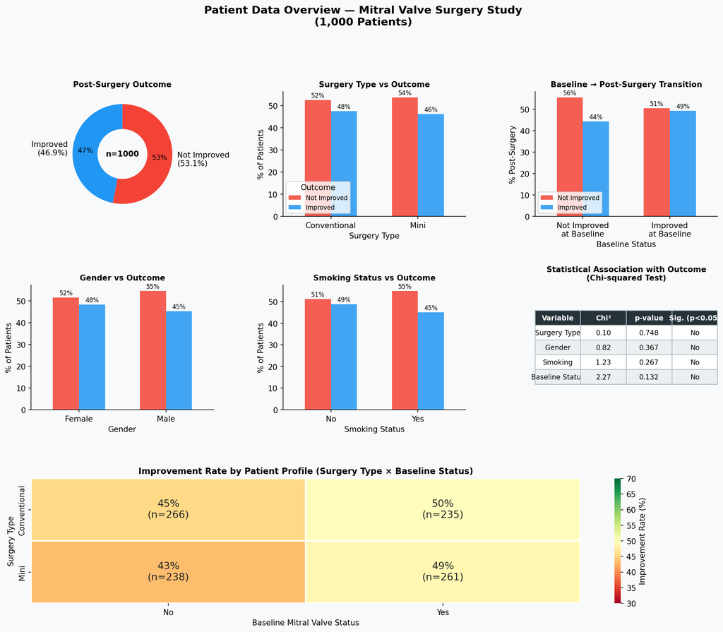

**How to read this:** These charts show how patients are distributed across different groups and how improvement rates vary. The heatmap (bottom) shows improvement rates for all combinations of surgery type and baseline status. The statistical table (middle right) tests whether any variable is significantly linked to outcome.

### Key Observations

**🔑 Critical Finding:** *None of the available variables — surgery type, gender, smoking status, or baseline valve status — showed a statistically significant association with post-surgery improvement* (all p-values > 0.13 on chi-squared tests). This means the data does not contain enough signal for a model to learn from.

**Surgery type:** Mini surgery and conventional surgery patients improved at nearly identical rates (~47%). The difference was not statistically meaningful.

**Gender:** Male and female patients showed almost identical improvement rates. Gender alone is not a useful predictor here.

**Smoking:** Smokers and non-smokers improved at similar rates. No meaningful clinical signal was found.

**Baseline status:** Intuitively, we might expect that patients already showing some improvement before surgery would be more likely to improve further. However, the data does not support this: patients with and without baseline improvement had similar post-surgery outcomes.

Section 05

## Our Approach — How We Built the Models

### Model Types (Explained Simply)

We tested six different types of prediction models, ranging from simple to complex. All models were asked the same question: given a patient's characteristics, will they improve?

| Model | Plain-English Explanation | Why We Included It |
| --- | --- | --- |
| **No-Skill Baseline** | Always predicts "Not Improved" — the most common outcome | Our floor. Any real model must beat this. |
| **Logistic Regression** | Estimates the probability of improvement using a weighted combination of predictors | Standard clinical baseline; transparent and interpretable |
| **KNN** | Finds the K most similar patients in the training data and uses their outcomes | Used in the original project; included for fair comparison |
| **SVM** | Draws the best possible boundary line between "Improved" and "Not Improved" patients | Used in the original project; included for fair comparison |
| **Random Forest** | Builds hundreds of decision trees and combines their votes | Industry standard for tabular healthcare data; handles mixed features well |
| **Gradient Boosting** | Builds trees sequentially, each one learning from the errors of the last | Often the best-performing model for structured clinical data |

### Validation Strategy — Ensuring Fair and Honest Results

We split the data into two separate groups: a **training set** (800 patients, 80%) used to teach the models, and a **test set** (200 patients, 20%) kept completely separate until the very end. This ensures we measure how well the model performs on patients it has never seen before — the only honest test of whether it would work in the real world.

During training, we used **10-fold cross-validation**: the training data was split 10 times into different training/validation sub-groups, and each model was evaluated on all 10 combinations. This gives us a stable, reliable estimate of performance.

### Evaluation Metrics (What Each One Means)

| Metric | What It Measures | Why It Matters in Healthcare |
| --- | --- | --- |
| **AUC (ROC)** | Overall ability to rank improved vs non-improved patients correctly | Best single summary; 0.5=random, 1.0=perfect |
| **Sensitivity** | % of truly improved patients the model correctly identifies | Critical: missing an improving patient means missing an opportunity to act |
| **Specificity** | % of non-improved patients the model correctly identifies | Prevents unnecessary interventions for patients who don't need them |
| **Precision (PPV)** | Of those the model calls "Improved", how many actually are? | Important for resource allocation — false positives waste clinical time |
| **F1 Score** | Balance between sensitivity and precision | Useful summary when both matter equally |

Section 06

## Results — What the Models Found

FIG 02

#### Model Performance — ROC Curves, AUC Scores, and Full Metrics Comparison

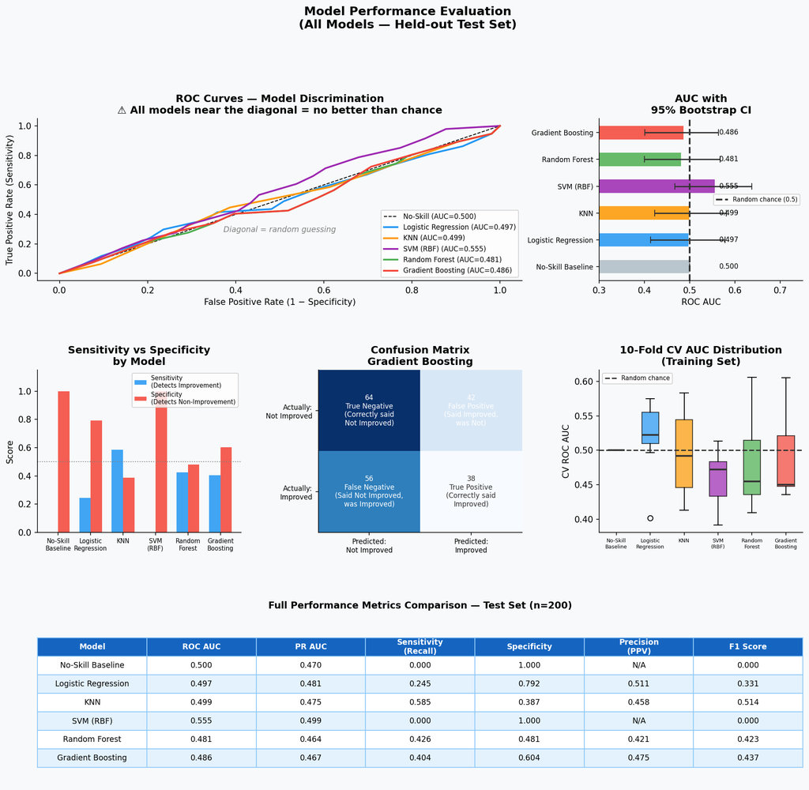

**ROC curves (top left):** A curve touching the top-left corner is perfect. A curve along the diagonal dashed line (as we see here) means the model is no better than a coin flip. **AUC bar chart (top right):** All models cluster around 0.50. **Metrics table (bottom):** Full performance breakdown for all six models.

### Summary of Results

| Model | AUC | Sensitivity | Specificity | F1 | Clinical Verdict |
| --- | --- | --- | --- | --- | --- |
| No-Skill Baseline | 0.500 | 0.00 | 1.00 | 0.00 | Floor — no use |
| Logistic Regression | 0.497 | 0.245 | 0.792 | 0.331 | Below chance |
| KNN | 0.499 | 0.585 | 0.387 | 0.514 | Random level |
| SVM (RBF) | 0.555 | 0.000 | 1.000 | 0.000 | Predicts nobody improves |
| Random Forest | 0.481 | 0.426 | 0.481 | 0.423 | Below chance |
| Gradient Boosting | 0.486 | 0.404 | 0.604 | 0.437 | Near random |

**⚠ Key Result:** All six models — including the most advanced (Random Forest and Gradient Boosting) — perform at or below random chance (AUC ≈ 0.50). The SVM model, despite appearing to have a slightly higher AUC (0.555), actually predicts that *no patient* will improve, giving it zero sensitivity — meaning it would be completely useless in a clinical setting.

### What About the Original KNN vs SVM Comparison?

The original project compared KNN and SVM and found SVM slightly better. Our expanded analysis confirms this finding — but also shows that both models, along with the more sophisticated Random Forest and Gradient Boosting, all fail at this prediction task. The conclusion is clear: *the limitation is in the data, not the model choice.*

Section 07

## What This Means — Clinical Interpretation

FIG 03

#### Model Interpretability — Feature Importance, Thresholds, and Calibration

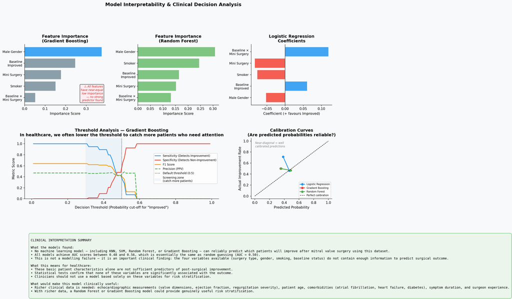

### A Note on Prediction vs Causation

⚠ Prediction ≠ Causation

Even if a model could predict outcomes accurately, that would not mean the predictors *cause* those outcomes. For example, if younger patients were found to improve more often, that doesn't mean age causes improvement — it may be confounded by other factors such as severity of disease or surgical fitness. Prediction models identify patterns; understanding the reasons behind those patterns requires careful clinical research and cannot be assumed from data alone.

### Should This Model Be Used for Clinical Decisions?

**No.** A model with AUC ≈ 0.50 performs no better than a coin flip. Using it to make clinical decisions — such as who receives more intensive monitoring or who is flagged as high-risk — would be meaningless and potentially harmful. We strongly advise against deploying any version of this model in a clinical setting until substantially richer data is available.

Section 08

## Limitations, Bias, and Ethical Considerations

### Data Limitations

**Too few clinical variables:** The most significant limitation is the dataset itself. Predicting cardiac surgical outcomes with only surgery type, gender, smoking, and baseline status is analogous to predicting exam results knowing only whether the student ate breakfast. The clinically meaningful predictors — valve dimensions, ejection fraction, severity scores, age, comorbidities — are absent.

**Dataset appears synthetic or anonymised:** The fact that no variable shows even a marginal statistical association with the outcome (all p > 0.13) is unusual in real clinical data. This dataset may have been constructed for teaching purposes rather than from genuine patient records, which limits the clinical relevance of any findings.

### Modelling Limitations

**Small feature space:** With only four binary predictors (plus one derived interaction), even the most powerful models have very little to work with. Gradient Boosting and Random Forest are designed to find subtle non-linear patterns — but those patterns must exist in the data first.

### Bias and Ethical Risks

**Gender and equity:** The inclusion of gender as a predictor requires careful ethical consideration. If a model systematically predicts worse outcomes for one gender, this could become a self-fulfilling prophecy that affects the quality of care offered. Predictors like gender should be used only where there is strong clinical evidence they are genuinely prognostic — not just statistically convenient.

**Do no harm:** The primary ethical obligation in clinical AI is to avoid causing harm. A model that incorrectly labels a patient as "unlikely to improve" could reduce the standard of care they receive. This risk is highest when models are used without clinical oversight.

**Transparency:** Any model used in clinical practice should be explainable to the patient and to the treating clinician. Black-box predictions are not acceptable in high-stakes medical settings.

Section 09

## Recommendations and Next Steps

### For This Dataset

- Collect richer clinical variables: echocardiographic measurements (ejection fraction, valve area, regurgitation grade), patient age, BMI, symptom severity scores, atrial fibrillation history, and comorbidities such as diabetes and renal disease.
- Increase sample size: with more patients and richer data, statistical power increases and models are more likely to find genuine clinical signals.
- Consider a prospective study: a carefully designed prospective clinical study with pre-defined outcome measures would produce data far more suitable for risk prediction modelling.

### For Future Modelling

- Continue using Random Forest and Gradient Boosting as the primary modelling approaches — they remain the most appropriate choice for tabular clinical data once richer predictors are available.
- Consider XGBoost or LightGBM once data quality improves — these handle complex interactions extremely well and are widely used in clinical outcome research.
- Always evaluate models on *calibration* as well as discrimination — a model used in clinical practice must produce reliable probability estimates, not just good rankings.
- Validate externally: any model trained on one hospital's data should be tested on data from other centres before it is considered for clinical use.

### For Clinical Practice

- Do not use any model derived from this dataset for clinical decisions — the data is insufficient.
- This work highlights the need for better surgical outcome data collection as part of routine clinical care.
- When a model does show genuine clinical utility (AUC ≥ 0.70 with good calibration), it should support — not replace — clinical judgement.

**✅ The Honest Value of This Study:** Demonstrating that a model cannot predict an outcome — and explaining *why* — is a legitimate and important scientific contribution. It tells us exactly what data needs to be collected next, and it prevents a flawed model from being deployed in a clinical setting where it could cause harm.